# BMS353 Bioinformatics for Biomedical Science - Week 6

Module Coordinator Mark Dunning

# Introduction

In the early days of microarray analysis, people were happy if they got a handful of differentially-expressed genes that they could validate or follow-up. However, with later technologies (and depending on the experimental setup) we might have thousands of statistically-significant results, which no-one has the time to follow-up. Also, we might be interested in pathways / mechanisms that are altered and not just individual genes.

In this section we move towards discovering if our results are *biologically significant*. Are the genes that we have picked statistical flukes, or are there some commonalities.

There are two different approaches one might use, and we will cover the theory behind both

There is also a bunch of websites for doing the tests + we will show how they are done in Bioconductor so the theory is clear

# Incorporating pathway data

We previously annotated our differential expression results to include gene names and description. The same annotation packages will also give us the names of the pathway(s) that each gene belongs to.

If you are missing this object, you can download using this link.

```r
results_annotated <- readRDS("Robjects/results_cellType_annotated.rds")
```

Let’s first filter our data to the genes that have statistical significance.

```r
## We need the dplyr library loaded before we can filter
library(dplyr)
de_genes <- results_annotated %>%
  filter(padj < 0.05, abs(log2FoldChange) > 1)
de_genes
```

| ENSEMBL | baseMean | log2FoldChange | lfcSE | stat | pvalue | padj | SYMBOL | GENENAME | ENTREZID |
| --- | --- | --- | --- | --- | --- | --- | --- | --- | --- |
| ENSMUSG00000027750 | 43151.80014 | -7.837807 | 0.14133207 | -55.456675 | 0.000000e+00 | 0.000000e+00 | Postn | periostin, osteoblast specific factor | 50706 |
| ENSMUSG00000022371 | 6723.35466 | -8.228116 | 0.23990509 | -34.297378 | 8.586338e-258 | 8.560150e-254 | Col14a1 | collagen, type XIV, alpha 1 | 12818 |
| ENSMUSG00000061048 | 4138.21908 | -7.055697 | 0.23453468 | -30.083811 | 7.890848e-199 | 5.244521e-195 | Cdh3 | cadherin 3 | 12560 |
| ENSMUSG00000061527 | 28962.27800 | -8.998817 | 0.30550879 | -29.455184 | 1.080509e-190 | 5.386067e-187 | Krt5 | keratin 5 | 110308 |
| ENSMUSG00000040118 | 2622.19811 | -8.334814 | 0.28716010 | -29.024973 | 3.185456e-185 | 1.270296e-181 | Cacna2d1 | calcium channel, voltage-dependent, alpha2/delta subunit 1 | 12293 |
| ENSMUSG00000058297 | 1716.67191 | -6.266885 | 0.21676081 | -28.911522 | 8.553966e-184 | 2.842625e-180 | Spock2 | sparc/osteonectin, cwcv and kazal-like domains proteoglycan 2 | 94214 |
| ENSMUSG00000049420 | 840.27467 | -8.826125 | 0.32646931 | -27.035083 | 5.720446e-161 | 1.629428e-157 | Tmem200a | transmembrane protein 200A | 77220 |
| ENSMUSG00000031503 | 23831.43797 | -6.785682 | 0.25206577 | -26.920282 | 1.271488e-159 | 3.169026e-156 | Col4a2 | collagen, type IV, alpha 2 | 12827 |
| ENSMUSG00000014773 | 8371.91578 | -7.118981 | 0.26572795 | -26.790487 | 4.170825e-158 | 9.240230e-155 | Dll1 | delta like canonical Notch ligand 1 | 13388 |
| ENSMUSG00000021604 | 1213.97709 | -8.512040 | 0.31918363 | -26.668159 | 1.102142e-156 | 2.197561e-153 | Irx4 | Iroquois homeobox 4 | 50916 |

[output cut: 990 more lines]

The organism package allows us to map between different identifiers

```r
library(org.Mm.eg.db)
```

Let’s remind ourselves of the mappings available as part of this package.

```r
columns(org.Mm.eg.db)
```

```
 [1] "ACCNUM"       "ALIAS"        "ENSEMBL"
 [4] "ENSEMBLPROT"  "ENSEMBLTRANS" "ENTREZID"
 [7] "ENZYME"       "EVIDENCE"     "EVIDENCEALL"
[10] "GENENAME"     "GO"           "GOALL"
[13] "IPI"          "MGI"          "ONTOLOGY"
[16] "ONTOLOGYALL"  "PATH"         "PFAM"
[19] "PMID"         "PROSITE"      "REFSEQ"
[22] "SYMBOL"       "UNIGENE"      "UNIPROT"
```

We can therefore find the pathways that are present amongst this list of genes using the `GO` column

```r
de_GO <- AnnotationDbi::select(org.Mm.eg.db, keys = de_genes$ENSEMBL,
                      keytype = "ENSEMBL",
                      columns = "GO")
```

```
keys and columns
```

```r
dplyr::count(de_GO, GO)
```

| GO | n |
| --- | --- |
| GO:0000002 | 3 |
| GO:0000003 | 1 |
| GO:0000012 | 1 |
| GO:0000014 | 4 |
| GO:0000016 | 2 |
| GO:0000017 | 2 |
| GO:0000026 | 3 |
| GO:0000028 | 4 |
| GO:0000030 | 5 |
| GO:0000032 | 1 |

[output cut: 990 more lines]

```r
dplyr::count(de_GO, GO) %>%
  arrange(desc(n))
```

| GO | n |
| --- | --- |
| GO:0005737 | 2839 |
| GO:0016020 | 2772 |
| GO:0005886 | 2375 |
| GO:0005634 | 2268 |
| GO:0016021 | 1908 |
| GO:0005515 | 1867 |
| GO:0005829 | 1330 |
| GO:0005615 | 1082 |
| GO:0046872 | 1052 |
| GO:0003674 | 950 |

[output cut: 990 more lines]

## Exercise

- Use the `AnnotationDbi::select` function to find the GO terms for all `ENSEMBL` IDs in the `results_annotated` data frame. How many entries are there for `GO:0016020`?
- What proportion of genes for this term were found to be differentially-expressed (also present in `de_genes`)?
- Is this enough information to decide whether the pathway is altered or not? What information are we not taking into account?

# Threshold-based Gene Set Testing

We are now building up our intuition for how threshold-based methods work. For a particular pathway we need to calculate how many genes were identified as differentially-expressed and compare to *how many we would be expect by chance*. Or in other words, if we repeatedly generated a list of differentially-expressed genes at random how many genes from this pathway would be expect to see.

For this particular pathway we can extract all genes as follows:-

```r
## The pull function from dplyr is used to extract a particular column

pathway_genes <- AnnotationDbi::select(org.Mm.eg.db,
                                       keys = "GO:0016020",
                                       keytype = "GO",
                                       columns="SYMBOL") %>% pull(SYMBOL)
```

```
keys and columns
```

We can then annotate each gene in our results according to whether it belongs to this pathway, and whether it is differentially-expressed.

```r
go_table <- mutate(results_annotated,
                   inPathway = SYMBOL %in% pathway_genes,
                   isDE = padj < 0.05 & abs(log2FoldChange) > 1)
go_table
```

| ENSEMBL | baseMean | log2FoldChange | lfcSE | stat | pvalue | padj | SYMBOL | GENENAME | ENTREZID | inPathway | isDE |
| --- | --- | --- | --- | --- | --- | --- | --- | --- | --- | --- | --- |
| ENSMUSG00000027750 | 43151.80014 | -7.8378069 | 0.14133207 | -55.456675 | 0.000000e+00 | 0.000000e+00 | Postn | periostin, osteoblast specific factor | 50706 | FALSE | TRUE |
| ENSMUSG00000022371 | 6723.35466 | -8.2281157 | 0.23990509 | -34.297378 | 8.586338e-258 | 8.560150e-254 | Col14a1 | collagen, type XIV, alpha 1 | 12818 | FALSE | TRUE |
| ENSMUSG00000061048 | 4138.21908 | -7.0556970 | 0.23453468 | -30.083811 | 7.890848e-199 | 5.244521e-195 | Cdh3 | cadherin 3 | 12560 | TRUE | TRUE |
| ENSMUSG00000061527 | 28962.27800 | -8.9988174 | 0.30550879 | -29.455184 | 1.080509e-190 | 5.386067e-187 | Krt5 | keratin 5 | 110308 | FALSE | TRUE |
| ENSMUSG00000040118 | 2622.19811 | -8.3348139 | 0.28716010 | -29.024973 | 3.185456e-185 | 1.270296e-181 | Cacna2d1 | calcium channel, voltage-dependent, alpha2/delta subunit 1 | 12293 | TRUE | TRUE |
| ENSMUSG00000058297 | 1716.67191 | -6.2668849 | 0.21676081 | -28.911522 | 8.553966e-184 | 2.842625e-180 | Spock2 | sparc/osteonectin, cwcv and kazal-like domains proteoglycan 2 | 94214 | FALSE | TRUE |
| ENSMUSG00000049420 | 840.27467 | -8.8261251 | 0.32646931 | -27.035083 | 5.720446e-161 | 1.629428e-157 | Tmem200a | transmembrane protein 200A | 77220 | TRUE | TRUE |
| ENSMUSG00000031503 | 23831.43797 | -6.7856817 | 0.25206577 | -26.920282 | 1.271488e-159 | 3.169026e-156 | Col4a2 | collagen, type IV, alpha 2 | 12827 | FALSE | TRUE |
| ENSMUSG00000014773 | 8371.91578 | -7.1189813 | 0.26572795 | -26.790487 | 4.170825e-158 | 9.240230e-155 | Dll1 | delta like canonical Notch ligand 1 | 13388 | TRUE | TRUE |
| ENSMUSG00000021604 | 1213.97709 | -8.5120399 | 0.31918363 | -26.668159 | 1.102142e-156 | 2.197561e-153 | Irx4 | Iroquois homeobox 4 | 50916 | FALSE | TRUE |

[output cut: 990 more lines]

Cross-tabulating the two new columns gives a basis for a statistical test

```r
table(go_table$inPathway, go_table$isDE)
```

```
        FALSE  TRUE
  FALSE 12978  4060
  TRUE   3403  2710
```

The Fisher’s exact test or chi-squared test (as seen here) can then be used

```r
chisq.test(table(go_table$inPathway, go_table$isDE))
```

```
    Pearson's Chi-squared test with Yates'
    continuity correction

data:  table(go_table$inPathway, go_table$isDE)
X-squared = 912.98, df = 1, p-value <
2.2e-16
```

In reality it would be impractical to test all possible pathways in this manner, so there are a number of Bioconductor packages that automate the process

## Analysis with clusterProfiler

`clusterProfiler` is another Bioconductor package for over-representation analysis. It’s main advantage is that it provides some nice visualisation methods.

The main function is `enrichGO` which requires the IDs of genes found to be differentially-expressed and the IDs of *all* genes in the dataset.

```r
library(clusterProfiler)
universe <- results_annotated %>% pull(ENTREZID)
sigGenes <- results_annotated %>%
  filter(padj < 0.05, !is.na(ENTREZID)) %>% pull(ENTREZID)

enrich_go <- enrichGO(
  gene= sigGenes,
  OrgDb = org.Mm.eg.db,
  keyType = "ENTREZID",
  ont = "BP",
  universe = universe,
  qvalueCutoff = 0.05,
  readable=TRUE
)
```

```r
enrich_go_tidy <- enrich_go %>%
  slot("result") %>%
  tibble::as.tibble()
```

```
`as.tibble()` is deprecated as of tibble 2.0.0.
Please use `as_tibble()` instead.
The signature and semantics have changed, see `?as_tibble`.
```

```r
enrich_go_tidy
```

| ID | Description | GeneRatio | BgRatio | pvalue | p.adjust | qvalue | geneID | Count |
| --- | --- | --- | --- | --- | --- | --- | --- | --- |
| GO:0031589 | cell-substrate adhesion | 237/8704 | 351/19999 | 5.309759e-20 | 3.349927e-16 | 2.312260e-16 | Postn/Spock2/Pdpn/Lrp1/Lamb1/Lgals1/Ntng2/Pcsk5/Cdh13/Antxr1…… | 237 |
| GO:1990778 | protein localization to cell periphery | 236/8704 | 362/19999 | 4.605350e-17 | 1.452758e-13 | 1.002754e-13 | Nectin3/Dchs1/Lrp1/Epb41/Clip3/Sptbn4/Nsg1/Nptx1/Gpc6/Epb41l…… | 236 |
| GO:0001667 | ameboidal-type cell migration | 267/8704 | 425/19999 | 4.887142e-16 | 1.027766e-12 | 7.094073e-13 | Snai2/Acta2/Bmp7/Ptprm/Marveld3/Sema6a/Sparc/Mef2c/Atoh8/Anx…… | 267 |
| GO:0072659 | protein localization to plasma membrane | 194/8704 | 294/19999 | 4.664997e-15 | 7.357866e-12 | 5.078708e-12 | Nectin3/Dchs1/Lrp1/Clip3/Sptbn4/Nsg1/Atp1b1/Wdr72/Lyplal1/Dl…… | 194 |
| GO:0030198 | extracellular matrix organization | 196/8704 | 301/19999 | 2.488053e-14 | 2.769031e-11 | 1.911301e-11 | Postn/Col14a1/Spock2/Col4a2/Eln/Loxl3/Pdpn/Col18a1/Col17a1/A…… | 196 |
| GO:0050808 | synapse organization | 289/8704 | 477/19999 | 2.633410e-14 | 2.769031e-11 | 1.911301e-11 | Cttnbp2/Sdk1/Homer1/Pcdhgc5/Col4a1/Get1/Sparc/Arc/Nrg2/Mef2c…… | 289 |
| GO:0043062 | extracellular structure organization | 196/8704 | 302/19999 | 4.052743e-14 | 3.652679e-11 | 2.521233e-11 | Postn/Col14a1/Spock2/Col4a2/Eln/Loxl3/Pdpn/Col18a1/Col17a1/A…… | 196 |
| GO:0007015 | actin filament organization | 262/8704 | 435/19999 | 1.090420e-12 | 8.599322e-10 | 5.935613e-10 | Eln/Tpm2/Dpysl3/Fhod3/Cap2/Cald1/Cotl1/Lmod1/Tpm1/Rflnb/Shan…… | 262 |
| GO:0007160 | cell-matrix adhesion | 144/8704 | 214/19999 | 1.586731e-12 | 1.112299e-09 | 7.677552e-10 | Postn/Lrp1/Pcsk5/Cdh13/Col16a1/Utrn/Vwa2/Otoa/Itgb7/Itga1/Pr…… | 144 |
| GO:0051271 | negative regulation of cellular component movement | 203/8704 | 324/19999 | 2.302400e-12 | 1.452584e-09 | 1.002635e-09 | Igfbp3/Ptprm/Lrp1/Dpysl3/Marveld3/Adgrg1/Sema6a/Ripor2/Mef2c…… | 203 |

[output cut: 990 more lines]

A dot plot can show us the most enriched pathways, and the size of each.

```
wrong orderBy parameter; set to default `orderBy = "x"`
```

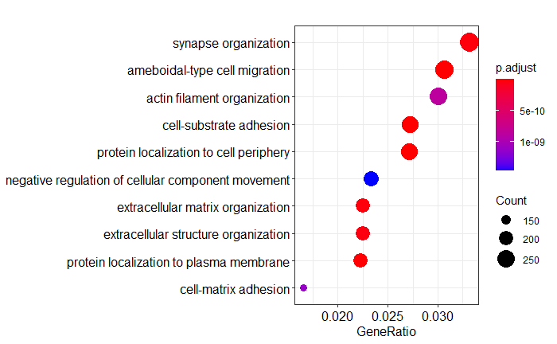

```r
dotplot(enrich_go)
```

```r
emapplot(enrich_go)
```

[output not shown]

# fgsea analysis

The fgsea package is a free implementation of the Broad’s GSEA software and is described in more detail in the package [vignette](http://www.bioconductor.org/packages/release/bioc/vignettes/fgsea/inst/doc/fgsea-tutorial.html) “fast preranked gene set enrichment analysis (GSEA)”:

The GSEA analysis is performed by:

- 1. ranking all genes in the data set based on their correlation to the chosen phenotype,
- 2. identifying the rank positions of all members of the gene set, and
- 3. calculating an enrichment score (ES) that represents the difference between the observed rankings and that which would be expected assuming a random rank distribution.

The article describing the original software is available [here](http://www.pnas.org/content/102/43/15545.long) and there is also a [commentary on GSEA](https://www.ncbi.nlm.nih.gov/pmc/articles/PMC1266131/).

In addition to the GSEA software the Broad also provide a number of very well curated gene sets for testing against your data - the Molecular Signatures Database (MSigDB). Unfortunately, these are collections of human genes. However, these lists have been translated to mouse equivalents by the Walter+Eliza Hall Institute’s Bioinformatics service and made available for download. These gene sets use *Entrez ID* as their identifier.

```r
library(fgsea)
```

An appealing feature of the method is that it does not require us to impose arbitrary cut-offs on the dataset to decide what is differentially-expressed or not. The steps in producing the input required for GSEA are i) retrieving the ranked statistics ii) naming each one according to Entrez ID.

```r
gseaInput <- filter(results_annotated, !is.na(ENTREZID), !is.na(stat)) %>%
  arrange(stat)
ranks <- pull(gseaInput,stat)
names(ranks) <- gseaInput$ENTREZID
```

Curated gene lists for mice can be downloaded from WEHI to our `Robjects` folder.

```r
download.file("http://bioinf.wehi.edu.au/MSigDB/v7.1/Mm.h.all.v7.1.entrez.rds", destfile = "Robjects/Mm.h.all.v7.1.entrez.rds")
Mm.H <- readRDS("Robjects/Mm.h.all.v7.1.entrez.rds")
pathways <- Mm.H
```

The analysis is now one call to the `fgsea` function. We can automatically exclude any pathways with too many or too few genes.

```r
library(fgsea)
fgseaRes <- fgsea(pathways, ranks, minSize=15, maxSize = 500)
dim(fgseaRes)
```

```
[1] 50  8
```

```r
#head(fgseaRes)
```

The results table gives the names of each pathway that was tested and the stats from doing the test. We can make this into a “tidy” object with the following code.

```r
fgseaResTidy <- fgseaRes %>%
  as_tibble() %>%
  arrange(desc(NES))

# Show in a nice table:
fgseaResTidy
```

| pathway | pval | padj | log2err | ES | NES | size | leadingEdge |
| --- | --- | --- | --- | --- | --- | --- | --- |
| HALLMARK_OXIDATIVE_PHOSPHORYLATION | 1.000000e-10 | 8.333333e-10 | NA | 0.5729808 | 2.4679040 | 218 |  |
| HALLMARK_PROTEIN_SECRETION | 1.923817e-05 | 9.619086e-05 | 0.57561026 | 0.4371753 | 1.7511124 | 132 |  |
| HALLMARK_FATTY_ACID_METABOLISM | 2.686725e-05 | 1.221239e-04 | 0.57561026 | 0.3737134 | 1.6145604 | 223 |  |
| HALLMARK_MYC_TARGETS_V1 | 1.504530e-04 | 6.268873e-04 | 0.51884808 | 0.3563644 | 1.5667554 | 253 |  |
| HALLMARK_REACTIVE_OXYGEN_SPECIES_PATHWAY | 5.427763e-03 | 1.356941e-02 | 0.40701792 | 0.4251501 | 1.5650827 | 71 |  |
| HALLMARK_E2F_TARGETS | 6.051651e-04 | 2.017217e-03 | 0.47727082 | 0.3272750 | 1.4468857 | 265 |  |
| HALLMARK_HEME_METABOLISM | 1.555008e-02 | 3.110016e-02 | 0.38073040 | 0.2880251 | 1.2667465 | 278 |  |
| HALLMARK_PEROXISOME | 9.362491e-02 | 1.462889e-01 | 0.28780513 | 0.2920481 | 1.2143432 | 157 |  |
| HALLMARK_DNA_REPAIR | 6.020784e-02 | 1.003464e-01 | 0.32177592 | 0.2848842 | 1.2124628 | 186 |  |
| HALLMARK_BILE_ACID_METABOLISM | 1.165919e-01 | 1.665599e-01 | 0.28201335 | 0.2834803 | 1.1712501 | 150 |  |

[output cut: 40 more lines]

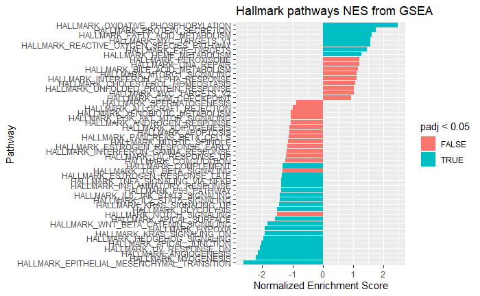

```r
library(ggplot2)
ggplot(fgseaResTidy, aes(reorder(pathway, NES), NES)) +
  geom_col(aes(fill=padj<0.05)) +
  coord_flip() +
  labs(x="Pathway", y="Normalized Enrichment Score",
       title="Hallmark pathways NES from GSEA")
```

The enrichment plot will show where the genes belonging to a particular gene set are towards the top or the bottom of the genelist, and how the *enrichment score* is calculated across the dataset.

Here we show the enrichment plot for the pathway with the most positive enrichment score.

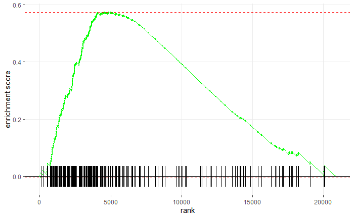

```r
plotEnrichment(pathways[["HALLMARK_OXIDATIVE_PHOSPHORYLATION"]],
               ranks)
```

# Creating Gene lists to use with an online tool

There are also many online tools that one could use to perform a gene set or ontology analysis.

- [DAVID](https://david.ncifcrf.gov/)
- [GeneTrail](https://genetrail2.bioinf.uni-sb.de/)
- [GORilla](http://cbl-gorilla.cs.technion.ac.il/)

The tools generally require your input genes lists to be uploaded as a simple text file. In this final challenge, we will create some files that you might use in one of these tools.

### A file containing names of background genes

This file has one column which lists **all the gene names** present in the analysis. Gene Symbols are commonly used, although a tool may accept Ensembl or Refseq names

### A file containing names of significant genes

This file has one column which lists the genes that passed the threshold for statistical significance (e.g. p-value less than 0.05) in your analysis. Gene Symbols are commonly used, although a tool may accept Ensembl or Refseq names

## Exercise

- Go to the homepage for GOrilla and review the data required for the running mode with *Two unranked lists of genes*
  - http://cbl-gorilla.cs.technion.ac.il/
- Produce the required inputs from your `results_annotated` data frame and run the enrichment analysis

# Getting Started with your assignment

Upon downloading your data, you should create a new RStudio project inside the same directory.

*File* -> *New Project*

then create a new Markdown file to document your analysis

*File* -> *New File* -> *R markdown*

Use the Knit drop-down menu to create a *Word* document from your analysis. It is advisable to do this often rather than waiting until you have completed your analysis.

The submitted document should contain only text and figures. When creating the Word you will need to set `echo=FALSE, warning=FALSE, message=FALSE` in all the *chunk options*.

See the file workflow_overview.Rmd for an example.

Good luck!

# Acknowledgements

**Original Authors: Belinda Phipson, Anna Trigos, Matt Ritchie, Maria Doyle, Harriet Dashnow, Charity Law**, **Stephane Ballereau, Oscar Rueda, Ashley Sawle** Based on the course [RNAseq analysis in R](http://combine-australia.github.io/2016-05-11-RNAseq/) delivered on May 11/12th 2016 and modified by Cancer Research Uk Cambridge Centre for the [Functional Genomics Autumn School 2017](https://bioinformatics-core-shared-training.github.io/cruk-autumn-school-2017/)

## Resources and data files

This material has been created using the following resources:  
http://www.statsci.org/smyth/pubs/QLedgeRPreprint.pdf http://monashbioinformaticsplatform.github.io/RNAseq-DE-analysis-with-R/99-RNAseq_DE_analysis_with_R.html  
http://bioconductor.org/packages/devel/bioc/vignettes/DESeq2/inst/doc/DESeq2.html https://bioconductor.github.io/BiocWorkshops/rna-seq-data-analysis-with-deseq2.html

This section also uses code from Stephen Turner’s guide to fgsea https://stephenturner.github.io/deseq-to-fgsea/